# eda slides

### Handling Missing Values

- **Objective:** Know how to handle null and missing values.

Sometimes, values will be missing from the source data or as a byproduct of manipulations. It is very important to detect missing data. Missing data can:

- Make the entire row ineligible to be training data for a model.
- Hint at data-collection errors.
- Indicate improper conversion or manipulation.
- Actually not be missing — it sometimes means "zero," "false," "not applicable," or "entered an empty string."

For example, a `.csv` file might have a missing value in some data fields:

```
tool_name,material,cost
hammer,wood,8
chainsaw,,
wrench,metal,5
```

When this data is imported, "null" values will be stored in the second row (in the "material" and "cost" columns).

> In Pandas, a "null" value is either `None` or `np.NaN` (Not a Number). Many fixed-size numeric datatypes (such as integers) do not have a way of representing `np.NaN`. So, numeric columns will be promoted to floating-point datatypes that do support it. For example, when importing the `.csv` file above:
> - **For the second row:** `None` will be stored in the "material" column and `np.NaN` will be stored in the "cost" column. The entire "cost" column (stored as a single `ndarray`) must be stored as floating-point values to accommodate the `np.NaN`, even though an integer `8` is in the first row.

```python
# Missing values are usually excluded in calculations by default.
drinks.continent.value_counts()              # Excludes missing values in the calculation
```

```
AF    53
EU    45
AS    44
OC    16
SA    12
Name: continent, dtype: int64
```

```python
# Includes missing values
drinks.continent.value_counts(dropna=False)
```

```
AF     53
EU     45
AS     44
NaN    23
OC     16
SA     12
Name: continent, dtype: int64
```

```python
# Find missing values in a Series.
# True if missing, False if not missing
drinks.continent.isnull()
```

```
0      False
1      False
2      False
3      False
4      False
5       True
6      False
7      False
8      False
9      False
10     False
11      True
12     False
13     False
14      True
```

[output cut: 47 more lines]

```python
# Count the missing values — sum() works because True is 1 and False is 0.
drinks.continent.isnull().sum()
```

```
23
```

```python
# True if not missing, False if missing
drinks.continent.notnull()
```

```
0       True
1       True
2       True
3       True
4       True
5      False
6       True
7       True
8       True
9       True
10      True
11     False
12      True
13      True
14     False
```

[output cut: 47 more lines]

```python
drinks.continent.notnull().sum()
```

```
170
```

```python
# Only show rows where continent is not missing.
drinks[drinks.continent.notnull()].head()
```

|  | country | beer | spirit | wine | liters | continent |
| --- | --- | --- | --- | --- | --- | --- |
| 0 | Afghanistan | 0 | 0 | 0 | 0.0 | AS |
| 1 | Albania | 89 | 132 | 54 | 4.9 | EU |
| 2 | Algeria | 25 | 0 | 14 | 0.7 | AF |
| 3 | Andorra | 245 | 138 | 312 | 12.4 | EU |
| 4 | Angola | 217 | 57 | 45 | 5.9 | AF |

**Find missing values in a `DataFrame`.**

```python
# DataFrame of Booleans
drinks.info()
```

[output not shown]

```
country       0
beer          0
spirit        0
wine          0
liters        0
continent    23
dtype: int64
```

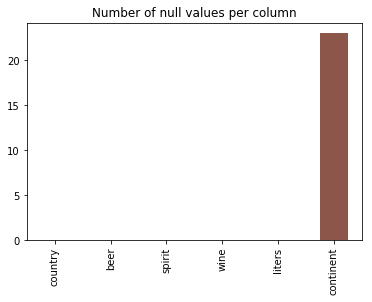

```python
# Count the missing values in each column — remember by default, axis=0.
print((drinks.isnull().sum()))

drinks.isnull().sum().plot(kind='bar');         # visually
plt.title('Number of null values per column');
```

**Dropping Missing Values**

```python
# Drop a row if ANY values are missing from any column — can be dangerous!
drinks.dropna()
```

|  | country | beer | spirit | wine | liters | continent |
| --- | --- | --- | --- | --- | --- | --- |
| 0 | Afghanistan | 0 | 0 | 0 | 0.0 | AS |
| 1 | Albania | 89 | 132 | 54 | 4.9 | EU |
| 2 | Algeria | 25 | 0 | 14 | 0.7 | AF |
| 3 | Andorra | 245 | 138 | 312 | 12.4 | EU |
| 4 | Angola | 217 | 57 | 45 | 5.9 | AF |
| 6 | Argentina | 193 | 25 | 221 | 8.3 | SA |
| 7 | Armenia | 21 | 179 | 11 | 3.8 | EU |
| 8 | Australia | 261 | 72 | 212 | 10.4 | OC |
| 9 | Austria | 279 | 75 | 191 | 9.7 | EU |
| 10 | Azerbaijan | 21 | 46 | 5 | 1.3 | EU |
| 12 | Bahrain | 42 | 63 | 7 | 2.0 | AS |
| 13 | Bangladesh | 0 | 0 | 0 | 0.0 | AS |
| 15 | Belarus | 142 | 373 | 42 | 14.4 | EU |
| 16 | Belgium | 295 | 84 | 212 | 10.5 | EU |
| 18 | Benin | 34 | 4 | 13 | 1.1 | AF |
| 19 | Bhutan | 23 | 0 | 0 | 0.4 | AS |
| 20 | Bolivia | 167 | 41 | 8 | 3.8 | SA |
| 21 | Bosnia-Herzegovina | 76 | 173 | 8 | 4.6 | EU |
| 22 | Botswana | 173 | 35 | 35 | 5.4 | AF |
| 23 | Brazil | 245 | 145 | 16 | 7.2 | SA |
| 24 | Brunei | 31 | 2 | 1 | 0.6 | AS |
| 25 | Bulgaria | 231 | 252 | 94 | 10.3 | EU |
| 26 | Burkina Faso | 25 | 7 | 7 | 4.3 | AF |
| 27 | Burundi | 88 | 0 | 0 | 6.3 | AF |
| 28 | Cote d'Ivoire | 37 | 1 | 7 | 4.0 | AF |
| 29 | Cabo Verde | 144 | 56 | 16 | 4.0 | AF |
| 30 | Cambodia | 57 | 65 | 1 | 2.2 | AS |
| 31 | Cameroon | 147 | 1 | 4 | 5.8 | AF |
| 33 | Central African Republic | 17 | 2 | 1 | 1.8 | AF |
| 34 | Chad | 15 | 1 | 1 | 0.4 | AF |
| ... | ... | ... | ... | ... | ... | ... |
| 161 | Sri Lanka | 16 | 104 | 0 | 2.2 | AS |
| 162 | Sudan | 8 | 13 | 0 | 1.7 | AF |
| 163 | Suriname | 128 | 178 | 7 | 5.6 | SA |
| 164 | Swaziland | 90 | 2 | 2 | 4.7 | AF |
| 165 | Sweden | 152 | 60 | 186 | 7.2 | EU |
| 166 | Switzerland | 185 | 100 | 280 | 10.2 | EU |
| 167 | Syria | 5 | 35 | 16 | 1.0 | AS |
| 168 | Tajikistan | 2 | 15 | 0 | 0.3 | AS |
| 169 | Thailand | 99 | 258 | 1 | 6.4 | AS |
| 170 | Macedonia | 106 | 27 | 86 | 3.9 | EU |
| 171 | Timor-Leste | 1 | 1 | 4 | 0.1 | AS |
| 172 | Togo | 36 | 2 | 19 | 1.3 | AF |
| 173 | Tonga | 36 | 21 | 5 | 1.1 | OC |
| 175 | Tunisia | 51 | 3 | 20 | 1.3 | AF |
| 176 | Turkey | 51 | 22 | 7 | 1.4 | AS |
| 177 | Turkmenistan | 19 | 71 | 32 | 2.2 | AS |
| 178 | Tuvalu | 6 | 41 | 9 | 1.0 | OC |
| 179 | Uganda | 45 | 9 | 0 | 8.3 | AF |
| 180 | Ukraine | 206 | 237 | 45 | 8.9 | EU |
| 181 | United Arab Emirates | 16 | 135 | 5 | 2.8 | AS |
| 182 | United Kingdom | 219 | 126 | 195 | 10.4 | EU |
| 183 | Tanzania | 36 | 6 | 1 | 5.7 | AF |
| 185 | Uruguay | 115 | 35 | 220 | 6.6 | SA |
| 186 | Uzbekistan | 25 | 101 | 8 | 2.4 | AS |
| 187 | Vanuatu | 21 | 18 | 11 | 0.9 | OC |
| 188 | Venezuela | 333 | 100 | 3 | 7.7 | SA |
| 189 | Vietnam | 111 | 2 | 1 | 2.0 | AS |
| 190 | Yemen | 6 | 0 | 0 | 0.1 | AS |
| 191 | Zambia | 32 | 19 | 4 | 2.5 | AF |
| 192 | Zimbabwe | 64 | 18 | 4 | 4.7 | AF |

170 rows × 6 columns

```python
# Drop a row only if ALL values are missing.
drinks.dropna(how='all')
```

|  | country | beer | spirit | wine | liters | continent |
| --- | --- | --- | --- | --- | --- | --- |
| 0 | Afghanistan | 0 | 0 | 0 | 0.0 | AS |
| 1 | Albania | 89 | 132 | 54 | 4.9 | EU |
| 2 | Algeria | 25 | 0 | 14 | 0.7 | AF |
| 3 | Andorra | 245 | 138 | 312 | 12.4 | EU |
| 4 | Angola | 217 | 57 | 45 | 5.9 | AF |
| 5 | Antigua & Barbuda | 102 | 128 | 45 | 4.9 | NaN |
| 6 | Argentina | 193 | 25 | 221 | 8.3 | SA |
| 7 | Armenia | 21 | 179 | 11 | 3.8 | EU |
| 8 | Australia | 261 | 72 | 212 | 10.4 | OC |
| 9 | Austria | 279 | 75 | 191 | 9.7 | EU |
| 10 | Azerbaijan | 21 | 46 | 5 | 1.3 | EU |
| 11 | Bahamas | 122 | 176 | 51 | 6.3 | NaN |
| 12 | Bahrain | 42 | 63 | 7 | 2.0 | AS |
| 13 | Bangladesh | 0 | 0 | 0 | 0.0 | AS |
| 14 | Barbados | 143 | 173 | 36 | 6.3 | NaN |
| 15 | Belarus | 142 | 373 | 42 | 14.4 | EU |
| 16 | Belgium | 295 | 84 | 212 | 10.5 | EU |
| 17 | Belize | 263 | 114 | 8 | 6.8 | NaN |
| 18 | Benin | 34 | 4 | 13 | 1.1 | AF |
| 19 | Bhutan | 23 | 0 | 0 | 0.4 | AS |
| 20 | Bolivia | 167 | 41 | 8 | 3.8 | SA |
| 21 | Bosnia-Herzegovina | 76 | 173 | 8 | 4.6 | EU |
| 22 | Botswana | 173 | 35 | 35 | 5.4 | AF |
| 23 | Brazil | 245 | 145 | 16 | 7.2 | SA |
| 24 | Brunei | 31 | 2 | 1 | 0.6 | AS |
| 25 | Bulgaria | 231 | 252 | 94 | 10.3 | EU |
| 26 | Burkina Faso | 25 | 7 | 7 | 4.3 | AF |
| 27 | Burundi | 88 | 0 | 0 | 6.3 | AF |
| 28 | Cote d'Ivoire | 37 | 1 | 7 | 4.0 | AF |
| 29 | Cabo Verde | 144 | 56 | 16 | 4.0 | AF |
| ... | ... | ... | ... | ... | ... | ... |
| 163 | Suriname | 128 | 178 | 7 | 5.6 | SA |
| 164 | Swaziland | 90 | 2 | 2 | 4.7 | AF |
| 165 | Sweden | 152 | 60 | 186 | 7.2 | EU |
| 166 | Switzerland | 185 | 100 | 280 | 10.2 | EU |
| 167 | Syria | 5 | 35 | 16 | 1.0 | AS |
| 168 | Tajikistan | 2 | 15 | 0 | 0.3 | AS |
| 169 | Thailand | 99 | 258 | 1 | 6.4 | AS |
| 170 | Macedonia | 106 | 27 | 86 | 3.9 | EU |
| 171 | Timor-Leste | 1 | 1 | 4 | 0.1 | AS |
| 172 | Togo | 36 | 2 | 19 | 1.3 | AF |
| 173 | Tonga | 36 | 21 | 5 | 1.1 | OC |
| 174 | Trinidad & Tobago | 197 | 156 | 7 | 6.4 | NaN |
| 175 | Tunisia | 51 | 3 | 20 | 1.3 | AF |
| 176 | Turkey | 51 | 22 | 7 | 1.4 | AS |
| 177 | Turkmenistan | 19 | 71 | 32 | 2.2 | AS |
| 178 | Tuvalu | 6 | 41 | 9 | 1.0 | OC |
| 179 | Uganda | 45 | 9 | 0 | 8.3 | AF |
| 180 | Ukraine | 206 | 237 | 45 | 8.9 | EU |
| 181 | United Arab Emirates | 16 | 135 | 5 | 2.8 | AS |
| 182 | United Kingdom | 219 | 126 | 195 | 10.4 | EU |
| 183 | Tanzania | 36 | 6 | 1 | 5.7 | AF |
| 184 | USA | 249 | 158 | 84 | 8.7 | NaN |
| 185 | Uruguay | 115 | 35 | 220 | 6.6 | SA |
| 186 | Uzbekistan | 25 | 101 | 8 | 2.4 | AS |
| 187 | Vanuatu | 21 | 18 | 11 | 0.9 | OC |
| 188 | Venezuela | 333 | 100 | 3 | 7.7 | SA |
| 189 | Vietnam | 111 | 2 | 1 | 2.0 | AS |
| 190 | Yemen | 6 | 0 | 0 | 0.1 | AS |
| 191 | Zambia | 32 | 19 | 4 | 2.5 | AF |
| 192 | Zimbabwe | 64 | 18 | 4 | 4.7 | AF |

193 rows × 6 columns

**Filling Missing Values**  
You may have noticed that the continent North America (NA) does not appear in the `continent` column. Pandas read in the original data and saw "NA", thought it was a missing value, and converted it to a `NaN`, missing value.

```python
# Fill in missing values with "NA" — this is dangerous to do without manually verifying them!
drinks.continent.fillna(value='NA')
```

```
0      AS
1      EU
2      AF
3      EU
4      AF
5      NA
6      SA
7      EU
8      OC
9      EU
10     EU
11     NA
12     AS
13     AS
14     NA
```

[output cut: 47 more lines]

```python
# Modifies "drinks" in-place
drinks.continent.fillna(value='NA', inplace=True)
```

```python
# Turn off the missing value filter — this is a better approach!
drinks = pd.read_csv('../data/drinks.csv', header=0, names=drink_cols, na_filter=False)
```

```python
drinks.continent.value_counts()
```

```
AF    53
EU    45
AS    44
NA    23
OC    16
SA    12
Name: continent, dtype: int64
```

```python
drinks.isnull().sum()
```

```
country      0
beer         0
spirit       0
wine         0
liters       0
continent    0
dtype: int64
```

### Split-Apply-Combine

- **Split:** We group data by continent.
- **Apply:** For each group, we apply the `mean()` function to find the average beer consumption.
- **Combine:** We now combine the continent names with the `mean()`s to produce a summary of our findings.

```python
# For each continent, calculate the mean beer servings.
drinks.groupby('continent').beer.mean()
```

[output not shown]

```python
# For each continent, calculate the mean of all numeric columns.
drinks.groupby('continent').mean()
```

[output not shown]

```python
# For each continent, describe beer servings.
drinks.groupby('continent').beer.describe()
```

[output not shown]

```python
# Similar, but outputs a DataFrame and can be customized — "agg" allows you to aggregate results of Series functions
drinks.groupby('continent').beer.agg(['count', 'mean', 'min', 'max'])
drinks.groupby('continent').beer.agg(['count', 'mean', 'min', 'max']).sort_values('mean')
```

[output not shown]

```python
# For each continent, describe all numeric columns.
drinks.groupby('continent').describe()
```

[output not shown]

```python
# For each continent, count the number of rows.
print((drinks.groupby('continent').continent.count()))
print((drinks.continent.value_counts()))   # should be the same
```

[output not shown]

### OPTIONAL: Other Commonly Used Features